# Risk Factor Analysis

## Outcome Variable

**Outcome Variable:** whz

## Predictor Variables

**Intervention Variable:** impsan

**Adjustment Set:**

- arm
- sex
- W_mage
- meducyrs
- feducyrs
- hhwealth_quart
- hfoodsec
- W_mhtcm
- W_nrooms
- W_nchldlt5
- W_parity
- impfloor
- safeh20
- delta_W_mage
- delta_meducyrs
- delta_feducyrs
- delta_hhwealth_quart
- delta_hfoodsec
- delta_W_mhtcm
- delta_W_nrooms
- delta_W_nchldlt5
- delta_W_parity
- delta_impfloor
- delta_safeh20

## Stratifying Variables

The analysis was stratified on these variable(s):

- agecat
- studyid
- country

## Data Summary

| agecat | studyid | country | impsan | n_cell | n |
| --- | --- | --- | --- | --- | --- |
| Birth | ki0047075b-MAL-ED | BANGLADESH | 1 | 186 | 222 |
| Birth | ki0047075b-MAL-ED | BANGLADESH | 0 | 36 | 222 |
| Birth | ki0047075b-MAL-ED | BRAZIL | 1 | 163 | 167 |
| Birth | ki0047075b-MAL-ED | BRAZIL | 0 | 4 | 167 |
| Birth | ki0047075b-MAL-ED | INDIA | 1 | 90 | 188 |
| Birth | ki0047075b-MAL-ED | INDIA | 0 | 98 | 188 |
| Birth | ki0047075b-MAL-ED | NEPAL | 1 | 165 | 166 |
| Birth | ki0047075b-MAL-ED | NEPAL | 0 | 1 | 166 |
| Birth | ki0047075b-MAL-ED | PERU | 1 | 60 | 243 |
| Birth | ki0047075b-MAL-ED | PERU | 0 | 183 | 243 |
| Birth | ki0047075b-MAL-ED | SOUTH AFRICA | 1 | 2 | 211 |
| Birth | ki0047075b-MAL-ED | SOUTH AFRICA | 0 | 209 | 211 |
| Birth | ki0047075b-MAL-ED | TANZANIA, UNITED REPUBLIC OF | 1 | 0 | 109 |
| Birth | ki0047075b-MAL-ED | TANZANIA, UNITED REPUBLIC OF | 0 | 109 | 109 |
| Birth | ki1017093-NIH-Birth | BANGLADESH | 1 | 9 | 28 |
| Birth | ki1017093-NIH-Birth | BANGLADESH | 0 | 19 | 28 |
| Birth | ki1017093c-NIH-Crypto | BANGLADESH | 1 | 21 | 23 |
| Birth | ki1017093c-NIH-Crypto | BANGLADESH | 0 | 2 | 23 |
| Birth | ki1114097-CONTENT | PERU | 1 | 1 | 2 |
| Birth | ki1114097-CONTENT | PERU | 0 | 1 | 2 |
| Birth | ki1135781-COHORTS | GUATEMALA | 1 | 43 | 449 |
| Birth | ki1135781-COHORTS | GUATEMALA | 0 | 406 | 449 |
| Birth | ki1135781-COHORTS | INDIA | 1 | 1685 | 4461 |
| Birth | ki1135781-COHORTS | INDIA | 0 | 2776 | 4461 |
| Birth | ki1135781-COHORTS | PHILIPPINES | 1 | 177 | 1126 |
| Birth | ki1135781-COHORTS | PHILIPPINES | 0 | 949 | 1126 |
| Birth | kiGH5241-JiVitA-3 | BANGLADESH | 1 | 10724 | 15689 |
| Birth | kiGH5241-JiVitA-3 | BANGLADESH | 0 | 4965 | 15689 |
| Birth | kiGH5241-JiVitA-4 | BANGLADESH | 1 | 503 | 683 |
| Birth | kiGH5241-JiVitA-4 | BANGLADESH | 0 | 180 | 683 |

[output cut: 68 more lines]

The following strata were considered:

- agecat: 24 months, studyid: ki0047075b-MAL-ED, country: BANGLADESH
- agecat: 24 months, studyid: ki0047075b-MAL-ED, country: BRAZIL
- agecat: 24 months, studyid: ki0047075b-MAL-ED, country: INDIA
- agecat: 24 months, studyid: ki0047075b-MAL-ED, country: NEPAL
- agecat: 24 months, studyid: ki0047075b-MAL-ED, country: PERU
- agecat: 24 months, studyid: ki0047075b-MAL-ED, country: SOUTH AFRICA
- agecat: 24 months, studyid: ki0047075b-MAL-ED, country: TANZANIA, UNITED REPUBLIC OF
- agecat: 24 months, studyid: ki1017093-NIH-Birth, country: BANGLADESH
- agecat: 24 months, studyid: ki1017093b-PROVIDE, country: BANGLADESH
- agecat: 24 months, studyid: ki1017093c-NIH-Crypto, country: BANGLADESH
- agecat: 24 months, studyid: ki1114097-CONTENT, country: PERU
- agecat: 24 months, studyid: ki1135781-COHORTS, country: GUATEMALA
- agecat: 24 months, studyid: ki1135781-COHORTS, country: INDIA
- agecat: 24 months, studyid: ki1135781-COHORTS, country: PHILIPPINES
- agecat: 24 months, studyid: ki1148112-LCNI-5, country: MALAWI
- agecat: 24 months, studyid: kiGH5241-JiVitA-3, country: BANGLADESH
- agecat: 24 months, studyid: kiGH5241-JiVitA-4, country: BANGLADESH
- agecat: 6 months, studyid: ki0047075b-MAL-ED, country: BANGLADESH
- agecat: 6 months, studyid: ki0047075b-MAL-ED, country: BRAZIL
- agecat: 6 months, studyid: ki0047075b-MAL-ED, country: INDIA
- agecat: 6 months, studyid: ki0047075b-MAL-ED, country: NEPAL
- agecat: 6 months, studyid: ki0047075b-MAL-ED, country: PERU
- agecat: 6 months, studyid: ki0047075b-MAL-ED, country: SOUTH AFRICA
- agecat: 6 months, studyid: ki0047075b-MAL-ED, country: TANZANIA, UNITED REPUBLIC OF
- agecat: 6 months, studyid: ki1017093-NIH-Birth, country: BANGLADESH
- agecat: 6 months, studyid: ki1017093b-PROVIDE, country: BANGLADESH
- agecat: 6 months, studyid: ki1017093c-NIH-Crypto, country: BANGLADESH
- agecat: 6 months, studyid: ki1114097-CONTENT, country: PERU
- agecat: 6 months, studyid: ki1135781-COHORTS, country: GUATEMALA
- agecat: 6 months, studyid: ki1135781-COHORTS, country: INDIA
- agecat: 6 months, studyid: ki1135781-COHORTS, country: PHILIPPINES
- agecat: 6 months, studyid: ki1148112-LCNI-5, country: MALAWI
- agecat: 6 months, studyid: kiGH5241-JiVitA-3, country: BANGLADESH
- agecat: 6 months, studyid: kiGH5241-JiVitA-4, country: BANGLADESH
- agecat: Birth, studyid: ki0047075b-MAL-ED, country: BANGLADESH
- agecat: Birth, studyid: ki0047075b-MAL-ED, country: BRAZIL
- agecat: Birth, studyid: ki0047075b-MAL-ED, country: INDIA
- agecat: Birth, studyid: ki0047075b-MAL-ED, country: NEPAL
- agecat: Birth, studyid: ki0047075b-MAL-ED, country: PERU
- agecat: Birth, studyid: ki0047075b-MAL-ED, country: SOUTH AFRICA
- agecat: Birth, studyid: ki0047075b-MAL-ED, country: TANZANIA, UNITED REPUBLIC OF
- agecat: Birth, studyid: ki1017093-NIH-Birth, country: BANGLADESH
- agecat: Birth, studyid: ki1017093c-NIH-Crypto, country: BANGLADESH
- agecat: Birth, studyid: ki1114097-CONTENT, country: PERU
- agecat: Birth, studyid: ki1135781-COHORTS, country: GUATEMALA
- agecat: Birth, studyid: ki1135781-COHORTS, country: INDIA
- agecat: Birth, studyid: ki1135781-COHORTS, country: PHILIPPINES
- agecat: Birth, studyid: kiGH5241-JiVitA-3, country: BANGLADESH
- agecat: Birth, studyid: kiGH5241-JiVitA-4, country: BANGLADESH

### Dropped Strata

Some strata were dropped due to rare outcomes:

- agecat: Birth, studyid: ki0047075b-MAL-ED, country: BRAZIL
- agecat: Birth, studyid: ki0047075b-MAL-ED, country: NEPAL
- agecat: Birth, studyid: ki0047075b-MAL-ED, country: SOUTH AFRICA
- agecat: Birth, studyid: ki0047075b-MAL-ED, country: TANZANIA, UNITED REPUBLIC OF
- agecat: Birth, studyid: ki1017093c-NIH-Crypto, country: BANGLADESH
- agecat: Birth, studyid: ki1114097-CONTENT, country: PERU
- agecat: 6 months, studyid: ki0047075b-MAL-ED, country: BRAZIL
- agecat: 6 months, studyid: ki0047075b-MAL-ED, country: NEPAL
- agecat: 6 months, studyid: ki0047075b-MAL-ED, country: SOUTH AFRICA
- agecat: 6 months, studyid: ki0047075b-MAL-ED, country: TANZANIA, UNITED REPUBLIC OF
- agecat: 6 months, studyid: ki1148112-LCNI-5, country: MALAWI
- agecat: 24 months, studyid: ki0047075b-MAL-ED, country: BRAZIL
- agecat: 24 months, studyid: ki0047075b-MAL-ED, country: NEPAL
- agecat: 24 months, studyid: ki0047075b-MAL-ED, country: SOUTH AFRICA
- agecat: 24 months, studyid: ki0047075b-MAL-ED, country: TANZANIA, UNITED REPUBLIC OF
- agecat: 24 months, studyid: ki1148112-LCNI-5, country: MALAWI

## Methods Detail

We’re interested in the causal parameters $E[Y_a]$ for all values of $a \in \mathcal{A}$. These parameters represent the mean outcome if, possibly contrary to fact, we intervened to set all units to have $A=a$. Under the randomization and positivity assumptions, these are identified by the statistical parameters $\psi_a=E_W[E_{Y|A,W}(Y|A=a,W)]$. In addition, we’re interested in the mean of $Y$, $E[Y]$ under no intervention (the observed mean). We will estimate these parameters by using SuperLearner to fit the relevant likelihood factors – $E_{Y|A,W}(Y|A=a,W)$ and $p(A=a|W)$, and then updating our likelihood fit using a joint TMLE.

For unadjusted analyses ($W=\{\}$), initial likelihoods were estimated using Lrnr_glm to estimate the simple $E(Y|A)$ and Lrnr_mean to estimate $p(A)$. For adjusted analyses, a small library containing Lrnr_glmnet, Lrnr_xgboost, and Lrnr_mean was used.

Having estimated these parameters, we will then use the delta method to estimate relative risks and attributable risks relative to a prespecified baseline level of $A$.

# Results Detail

## Results Plots

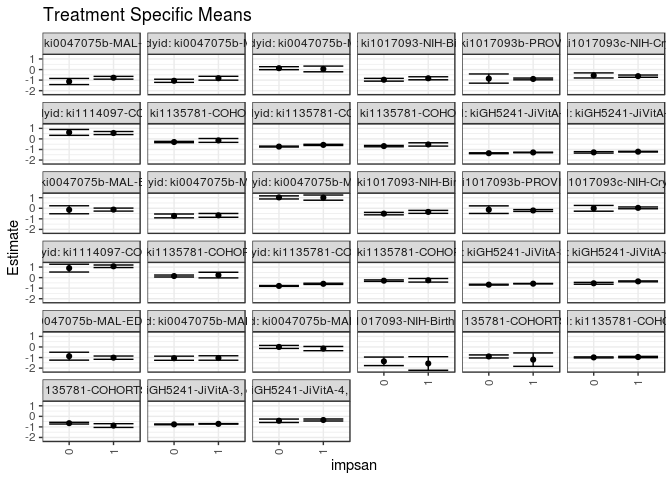

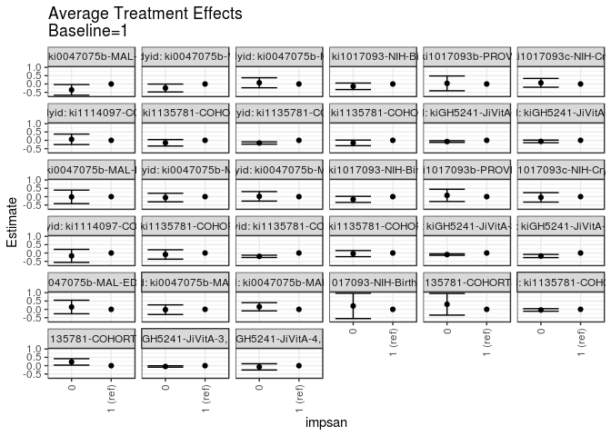

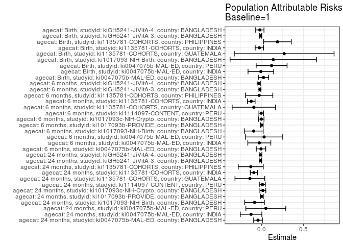

## Results Table

### Parameter: TSM

| agecat | studyid | country | intervention_level | baseline_level | estimate | ci_lower | ci_upper |
| --- | --- | --- | --- | --- | --- | --- | --- |
| Birth | ki0047075b-MAL-ED | BANGLADESH | 1 | NA | -1.0118847 | -1.1674887 | -0.8562808 |
| Birth | ki0047075b-MAL-ED | BANGLADESH | 0 | NA | -0.8715091 | -1.2455960 | -0.4974221 |
| Birth | ki0047075b-MAL-ED | INDIA | 1 | NA | -1.0437781 | -1.2555564 | -0.8319998 |
| Birth | ki0047075b-MAL-ED | INDIA | 0 | NA | -1.0648964 | -1.2600617 | -0.8697312 |
| Birth | ki0047075b-MAL-ED | PERU | 1 | NA | -0.1502807 | -0.3508003 | 0.0502388 |
| Birth | ki0047075b-MAL-ED | PERU | 0 | NA | 0.0044962 | -0.1367169 | 0.1457093 |
| Birth | ki1017093-NIH-Birth | BANGLADESH | 1 | NA | -1.5622222 | -2.2052846 | -0.9191599 |
| Birth | ki1017093-NIH-Birth | BANGLADESH | 0 | NA | -1.3584211 | -1.7618042 | -0.9550379 |
| Birth | ki1135781-COHORTS | GUATEMALA | 1 | NA | -1.1983821 | -1.8329847 | -0.5637794 |
| Birth | ki1135781-COHORTS | GUATEMALA | 0 | NA | -0.8951878 | -1.0385055 | -0.7518700 |
| Birth | ki1135781-COHORTS | INDIA | 1 | NA | -0.9494603 | -1.0115867 | -0.8873339 |
| Birth | ki1135781-COHORTS | INDIA | 0 | NA | -0.9868334 | -1.0316041 | -0.9420627 |
| Birth | ki1135781-COHORTS | PHILIPPINES | 1 | NA | -0.8728512 | -1.0489773 | -0.6967252 |
| Birth | ki1135781-COHORTS | PHILIPPINES | 0 | NA | -0.6473846 | -0.7285516 | -0.5662176 |
| Birth | kiGH5241-JiVitA-3 | BANGLADESH | 1 | NA | -0.7119095 | -0.7363527 | -0.6874663 |
| Birth | kiGH5241-JiVitA-3 | BANGLADESH | 0 | NA | -0.7593510 | -0.7940368 | -0.7246651 |
| Birth | kiGH5241-JiVitA-4 | BANGLADESH | 1 | NA | -0.3462401 | -0.4412547 | -0.2512256 |
| Birth | kiGH5241-JiVitA-4 | BANGLADESH | 0 | NA | -0.4181791 | -0.5786290 | -0.2577293 |
| 6 months | ki0047075b-MAL-ED | BANGLADESH | 1 | NA | -0.1273852 | -0.2687234 | 0.0139529 |
| 6 months | ki0047075b-MAL-ED | BANGLADESH | 0 | NA | -0.1413198 | -0.5214188 | 0.2387792 |
| 6 months | ki0047075b-MAL-ED | INDIA | 1 | NA | -0.6721364 | -0.8526360 | -0.4916367 |
| 6 months | ki0047075b-MAL-ED | INDIA | 0 | NA | -0.7253923 | -0.9082705 | -0.5425142 |
| 6 months | ki0047075b-MAL-ED | PERU | 1 | NA | 1.0084856 | 0.7638044 | 1.2531668 |
| 6 months | ki0047075b-MAL-ED | PERU | 0 | NA | 1.0282623 | 0.8815624 | 1.1749623 |
| 6 months | ki1017093-NIH-Birth | BANGLADESH | 1 | NA | -0.3437524 | -0.4846638 | -0.2028410 |
| 6 months | ki1017093-NIH-Birth | BANGLADESH | 0 | NA | -0.5070938 | -0.6221175 | -0.3920701 |
| 6 months | ki1017093b-PROVIDE | BANGLADESH | 1 | NA | -0.2097711 | -0.2971742 | -0.1223681 |
| 6 months | ki1017093b-PROVIDE | BANGLADESH | 0 | NA | -0.1324983 | -0.4916059 | 0.2266094 |
| 6 months | ki1017093c-NIH-Crypto | BANGLADESH | 1 | NA | 0.0381613 | -0.0456839 | 0.1220065 |
| 6 months | ki1017093c-NIH-Crypto | BANGLADESH | 0 | NA | -0.0045517 | -0.2777333 | 0.2686298 |
| 6 months | ki1114097-CONTENT | PERU | 1 | NA | 1.0741048 | 0.9519103 | 1.1962992 |
| 6 months | ki1114097-CONTENT | PERU | 0 | NA | 0.9010901 | 0.5319887 | 1.2701915 |
| 6 months | ki1135781-COHORTS | GUATEMALA | 1 | NA | 0.2396553 | -0.0278703 | 0.5071808 |
| 6 months | ki1135781-COHORTS | GUATEMALA | 0 | NA | 0.1513934 | 0.0587781 | 0.2440087 |
| 6 months | ki1135781-COHORTS | INDIA | 1 | NA | -0.5856481 | -0.6409041 | -0.5303920 |
| 6 months | ki1135781-COHORTS | INDIA | 0 | NA | -0.7871077 | -0.8291221 | -0.7450932 |
| 6 months | ki1135781-COHORTS | PHILIPPINES | 1 | NA | -0.2528557 | -0.4227589 | -0.0829525 |
| 6 months | ki1135781-COHORTS | PHILIPPINES | 0 | NA | -0.2888207 | -0.3589833 | -0.2186582 |
| 6 months | kiGH5241-JiVitA-3 | BANGLADESH | 1 | NA | -0.5718193 | -0.5946285 | -0.5490100 |
| 6 months | kiGH5241-JiVitA-3 | BANGLADESH | 0 | NA | -0.6664489 | -0.7059156 | -0.6269822 |
| 6 months | kiGH5241-JiVitA-4 | BANGLADESH | 1 | NA | -0.3547099 | -0.3962430 | -0.3131767 |
| 6 months | kiGH5241-JiVitA-4 | BANGLADESH | 0 | NA | -0.5356175 | -0.6232408 | -0.4479942 |
| 24 months | ki0047075b-MAL-ED | BANGLADESH | 1 | NA | -0.7769540 | -0.9088248 | -0.6450832 |
| 24 months | ki0047075b-MAL-ED | BANGLADESH | 0 | NA | -1.1319782 | -1.4230836 | -0.8408728 |
| 24 months | ki0047075b-MAL-ED | INDIA | 1 | NA | -0.8225199 | -1.0041313 | -0.6409085 |
| 24 months | ki0047075b-MAL-ED | INDIA | 0 | NA | -1.0647216 | -1.2130687 | -0.9163745 |
| 24 months | ki0047075b-MAL-ED | PERU | 1 | NA | 0.0568829 | -0.2121730 | 0.3259388 |
| 24 months | ki0047075b-MAL-ED | PERU | 0 | NA | 0.1294045 | -0.0101534 | 0.2689624 |
| 24 months | ki1017093-NIH-Birth | BANGLADESH | 1 | NA | -0.8262117 | -0.9703131 | -0.6821103 |
| 24 months | ki1017093-NIH-Birth | BANGLADESH | 0 | NA | -0.9664683 | -1.0977135 | -0.8352230 |
| 24 months | ki1017093b-PROVIDE | BANGLADESH | 1 | NA | -0.8912738 | -0.9761024 | -0.8064452 |
| 24 months | ki1017093b-PROVIDE | BANGLADESH | 0 | NA | -0.8543865 | -1.2919569 | -0.4168160 |
| 24 months | ki1017093c-NIH-Crypto | BANGLADESH | 1 | NA | -0.6256046 | -0.7305174 | -0.5206918 |
| 24 months | ki1017093c-NIH-Crypto | BANGLADESH | 0 | NA | -0.5573779 | -0.7989494 | -0.3158064 |
| 24 months | ki1114097-CONTENT | PERU | 1 | NA | 0.5570157 | 0.4105999 | 0.7034315 |
| 24 months | ki1114097-CONTENT | PERU | 0 | NA | 0.6160078 | 0.3384999 | 0.8935157 |
| 24 months | ki1135781-COHORTS | GUATEMALA | 1 | NA | -0.1451358 | -0.3284438 | 0.0381722 |
| 24 months | ki1135781-COHORTS | GUATEMALA | 0 | NA | -0.2949205 | -0.3576825 | -0.2321584 |
| 24 months | ki1135781-COHORTS | INDIA | 1 | NA | -0.5671099 | -0.6208065 | -0.5134133 |
| 24 months | ki1135781-COHORTS | INDIA | 0 | NA | -0.7279514 | -0.7707763 | -0.6851264 |
| 24 months | ki1135781-COHORTS | PHILIPPINES | 1 | NA | -0.5257132 | -0.6824858 | -0.3689405 |
| 24 months | ki1135781-COHORTS | PHILIPPINES | 0 | NA | -0.6811876 | -0.7439806 | -0.6183946 |
| 24 months | kiGH5241-JiVitA-3 | BANGLADESH | 1 | NA | -1.2818850 | -1.3101654 | -1.2536047 |
| 24 months | kiGH5241-JiVitA-3 | BANGLADESH | 0 | NA | -1.3549910 | -1.3989704 | -1.3110116 |
| 24 months | kiGH5241-JiVitA-4 | BANGLADESH | 1 | NA | -1.2097362 | -1.2447005 | -1.1747719 |
| 24 months | kiGH5241-JiVitA-4 | BANGLADESH | 0 | NA | -1.2751774 | -1.3449459 | -1.2054089 |

### Parameter: E(Y)

| agecat | studyid | country | intervention_level | baseline_level | estimate | ci_lower | ci_upper |
| --- | --- | --- | --- | --- | --- | --- | --- |
| Birth | ki0047075b-MAL-ED | BANGLADESH | NA | NA | -0.9902252 | -1.1311070 | -0.8493435 |
| Birth | ki0047075b-MAL-ED | INDIA | NA | NA | -1.0536702 | -1.1965043 | -0.9108361 |
| Birth | ki0047075b-MAL-ED | PERU | NA | NA | -0.0315638 | -0.1495606 | 0.0864330 |
| Birth | ki1017093-NIH-Birth | BANGLADESH | NA | NA | -1.4239286 | -1.7688028 | -1.0790544 |
| Birth | ki1135781-COHORTS | GUATEMALA | NA | NA | -0.9294432 | -1.0701697 | -0.7887168 |
| Birth | ki1135781-COHORTS | INDIA | NA | NA | -0.9771733 | -1.0119896 | -0.9423570 |
| Birth | ki1135781-COHORTS | PHILIPPINES | NA | NA | -0.6841030 | -0.7582767 | -0.6099293 |
| Birth | kiGH5241-JiVitA-3 | BANGLADESH | NA | NA | -0.7238913 | -0.7437437 | -0.7040388 |
| Birth | kiGH5241-JiVitA-4 | BANGLADESH | NA | NA | -0.3683163 | -0.4490504 | -0.2875821 |
| 6 months | ki0047075b-MAL-ED | BANGLADESH | NA | NA | -0.1354618 | -0.2647919 | -0.0061317 |
| 6 months | ki0047075b-MAL-ED | INDIA | NA | NA | -0.7004578 | -0.8268704 | -0.5740452 |
| 6 months | ki0047075b-MAL-ED | PERU | NA | NA | 1.0376236 | 0.9141918 | 1.1610554 |
| 6 months | ki1017093-NIH-Birth | BANGLADESH | NA | NA | -0.4389101 | -0.5279432 | -0.3498771 |
| 6 months | ki1017093b-PROVIDE | BANGLADESH | NA | NA | -0.2080201 | -0.2927357 | -0.1233045 |
| 6 months | ki1017093c-NIH-Crypto | BANGLADESH | NA | NA | 0.0336790 | -0.0458848 | 0.1132428 |
| 6 months | ki1114097-CONTENT | PERU | NA | NA | 1.0684318 | 0.9515274 | 1.1853362 |
| 6 months | ki1135781-COHORTS | GUATEMALA | NA | NA | 0.1458511 | 0.0589571 | 0.2327450 |
| 6 months | ki1135781-COHORTS | INDIA | NA | NA | -0.7104855 | -0.7428053 | -0.6781657 |
| 6 months | ki1135781-COHORTS | PHILIPPINES | NA | NA | -0.2830286 | -0.3471028 | -0.2189545 |
| 6 months | kiGH5241-JiVitA-3 | BANGLADESH | NA | NA | -0.5931476 | -0.6127125 | -0.5735828 |
| 6 months | kiGH5241-JiVitA-4 | BANGLADESH | NA | NA | -0.3901595 | -0.4274150 | -0.3529041 |
| 24 months | ki0047075b-MAL-ED | BANGLADESH | NA | NA | -0.8208255 | -0.9429246 | -0.6987264 |
| 24 months | ki0047075b-MAL-ED | INDIA | NA | NA | -0.9496667 | -1.0657716 | -0.8335618 |
| 24 months | ki0047075b-MAL-ED | PERU | NA | NA | 0.1064286 | -0.0147106 | 0.2275677 |
| 24 months | ki1017093-NIH-Birth | BANGLADESH | NA | NA | -0.9115790 | -1.0095022 | -0.8136559 |
| 24 months | ki1017093b-PROVIDE | BANGLADESH | NA | NA | -0.8896187 | -0.9726240 | -0.8066134 |
| 24 months | ki1017093c-NIH-Crypto | BANGLADESH | NA | NA | -0.6115706 | -0.7075788 | -0.5155624 |
| 24 months | ki1114097-CONTENT | PERU | NA | NA | 0.5668293 | 0.4302437 | 0.7034148 |
| 24 months | ki1135781-COHORTS | GUATEMALA | NA | NA | -0.2861905 | -0.3461594 | -0.2262216 |
| 24 months | ki1135781-COHORTS | INDIA | NA | NA | -0.6606874 | -0.6938402 | -0.6275347 |
| 24 months | ki1135781-COHORTS | PHILIPPINES | NA | NA | -0.6564149 | -0.7144543 | -0.5983756 |
| 24 months | kiGH5241-JiVitA-3 | BANGLADESH | NA | NA | -1.2970418 | -1.3203361 | -1.2737475 |
| 24 months | kiGH5241-JiVitA-4 | BANGLADESH | NA | NA | -1.2231776 | -1.2550332 | -1.1913220 |

### Parameter: ATE

| agecat | studyid | country | intervention_level | baseline_level | estimate | ci_lower | ci_upper |
| --- | --- | --- | --- | --- | --- | --- | --- |
| Birth | ki0047075b-MAL-ED | BANGLADESH | 1 | 1 | 0.0000000 | 0.0000000 | 0.0000000 |
| Birth | ki0047075b-MAL-ED | BANGLADESH | 0 | 1 | 0.1403757 | -0.2661750 | 0.5469263 |
| Birth | ki0047075b-MAL-ED | INDIA | 1 | 1 | 0.0000000 | 0.0000000 | 0.0000000 |
| Birth | ki0047075b-MAL-ED | INDIA | 0 | 1 | -0.0211184 | -0.3107795 | 0.2685427 |
| Birth | ki0047075b-MAL-ED | PERU | 1 | 1 | 0.0000000 | 0.0000000 | 0.0000000 |
| Birth | ki0047075b-MAL-ED | PERU | 0 | 1 | 0.1547770 | -0.0911472 | 0.4007012 |
| Birth | ki1017093-NIH-Birth | BANGLADESH | 1 | 1 | 0.0000000 | 0.0000000 | 0.0000000 |
| Birth | ki1017093-NIH-Birth | BANGLADESH | 0 | 1 | 0.2038012 | -0.5553083 | 0.9629106 |
| Birth | ki1135781-COHORTS | GUATEMALA | 1 | 1 | 0.0000000 | 0.0000000 | 0.0000000 |
| Birth | ki1135781-COHORTS | GUATEMALA | 0 | 1 | 0.3031943 | -0.3476945 | 0.9540831 |
| Birth | ki1135781-COHORTS | INDIA | 1 | 1 | 0.0000000 | 0.0000000 | 0.0000000 |
| Birth | ki1135781-COHORTS | INDIA | 0 | 1 | -0.0373731 | -0.1138856 | 0.0391394 |
| Birth | ki1135781-COHORTS | PHILIPPINES | 1 | 1 | 0.0000000 | 0.0000000 | 0.0000000 |
| Birth | ki1135781-COHORTS | PHILIPPINES | 0 | 1 | 0.2254666 | 0.0320443 | 0.4188889 |
| Birth | kiGH5241-JiVitA-3 | BANGLADESH | 1 | 1 | 0.0000000 | 0.0000000 | 0.0000000 |
| Birth | kiGH5241-JiVitA-3 | BANGLADESH | 0 | 1 | -0.0474414 | -0.0879654 | -0.0069175 |
| Birth | kiGH5241-JiVitA-4 | BANGLADESH | 1 | 1 | 0.0000000 | 0.0000000 | 0.0000000 |
| Birth | kiGH5241-JiVitA-4 | BANGLADESH | 0 | 1 | -0.0719390 | -0.2596372 | 0.1157592 |
| 6 months | ki0047075b-MAL-ED | BANGLADESH | 1 | 1 | 0.0000000 | 0.0000000 | 0.0000000 |
| 6 months | ki0047075b-MAL-ED | BANGLADESH | 0 | 1 | -0.0139346 | -0.4202477 | 0.3923786 |
| 6 months | ki0047075b-MAL-ED | INDIA | 1 | 1 | 0.0000000 | 0.0000000 | 0.0000000 |
| 6 months | ki0047075b-MAL-ED | INDIA | 0 | 1 | -0.0532560 | -0.3106624 | 0.2041505 |
| 6 months | ki0047075b-MAL-ED | PERU | 1 | 1 | 0.0000000 | 0.0000000 | 0.0000000 |
| 6 months | ki0047075b-MAL-ED | PERU | 0 | 1 | 0.0197767 | -0.2668903 | 0.3064437 |
| 6 months | ki1017093-NIH-Birth | BANGLADESH | 1 | 1 | 0.0000000 | 0.0000000 | 0.0000000 |
| 6 months | ki1017093-NIH-Birth | BANGLADESH | 0 | 1 | -0.1633414 | -0.3456432 | 0.0189604 |
| 6 months | ki1017093b-PROVIDE | BANGLADESH | 1 | 1 | 0.0000000 | 0.0000000 | 0.0000000 |
| 6 months | ki1017093b-PROVIDE | BANGLADESH | 0 | 1 | 0.0772728 | -0.2916220 | 0.4461677 |
| 6 months | ki1017093c-NIH-Crypto | BANGLADESH | 1 | 1 | 0.0000000 | 0.0000000 | 0.0000000 |
| 6 months | ki1017093c-NIH-Crypto | BANGLADESH | 0 | 1 | -0.0427130 | -0.3281555 | 0.2427294 |
| 6 months | ki1114097-CONTENT | PERU | 1 | 1 | 0.0000000 | 0.0000000 | 0.0000000 |
| 6 months | ki1114097-CONTENT | PERU | 0 | 1 | -0.1730147 | -0.5639077 | 0.2178783 |
| 6 months | ki1135781-COHORTS | GUATEMALA | 1 | 1 | 0.0000000 | 0.0000000 | 0.0000000 |
| 6 months | ki1135781-COHORTS | GUATEMALA | 0 | 1 | -0.0882619 | -0.3718578 | 0.1953340 |
| 6 months | ki1135781-COHORTS | INDIA | 1 | 1 | 0.0000000 | 0.0000000 | 0.0000000 |
| 6 months | ki1135781-COHORTS | INDIA | 0 | 1 | -0.2014596 | -0.2707725 | -0.1321467 |
| 6 months | ki1135781-COHORTS | PHILIPPINES | 1 | 1 | 0.0000000 | 0.0000000 | 0.0000000 |
| 6 months | ki1135781-COHORTS | PHILIPPINES | 0 | 1 | -0.0359650 | -0.2202516 | 0.1483215 |
| 6 months | kiGH5241-JiVitA-3 | BANGLADESH | 1 | 1 | 0.0000000 | 0.0000000 | 0.0000000 |
| 6 months | kiGH5241-JiVitA-3 | BANGLADESH | 0 | 1 | -0.0946296 | -0.1382979 | -0.0509613 |
| 6 months | kiGH5241-JiVitA-4 | BANGLADESH | 1 | 1 | 0.0000000 | 0.0000000 | 0.0000000 |
| 6 months | kiGH5241-JiVitA-4 | BANGLADESH | 0 | 1 | -0.1809076 | -0.2768684 | -0.0849469 |
| 24 months | ki0047075b-MAL-ED | BANGLADESH | 1 | 1 | 0.0000000 | 0.0000000 | 0.0000000 |
| 24 months | ki0047075b-MAL-ED | BANGLADESH | 0 | 1 | -0.3550242 | -0.6759254 | -0.0341229 |
| 24 months | ki0047075b-MAL-ED | INDIA | 1 | 1 | 0.0000000 | 0.0000000 | 0.0000000 |
| 24 months | ki0047075b-MAL-ED | INDIA | 0 | 1 | -0.2422017 | -0.4780440 | -0.0063594 |
| 24 months | ki0047075b-MAL-ED | PERU | 1 | 1 | 0.0000000 | 0.0000000 | 0.0000000 |
| 24 months | ki0047075b-MAL-ED | PERU | 0 | 1 | 0.0725216 | -0.2287203 | 0.3737635 |
| 24 months | ki1017093-NIH-Birth | BANGLADESH | 1 | 1 | 0.0000000 | 0.0000000 | 0.0000000 |
| 24 months | ki1017093-NIH-Birth | BANGLADESH | 0 | 1 | -0.1402566 | -0.3353478 | 0.0548347 |
| 24 months | ki1017093b-PROVIDE | BANGLADESH | 1 | 1 | 0.0000000 | 0.0000000 | 0.0000000 |
| 24 months | ki1017093b-PROVIDE | BANGLADESH | 0 | 1 | 0.0368873 | -0.4086372 | 0.4824118 |
| 24 months | ki1017093c-NIH-Crypto | BANGLADESH | 1 | 1 | 0.0000000 | 0.0000000 | 0.0000000 |
| 24 months | ki1017093c-NIH-Crypto | BANGLADESH | 0 | 1 | 0.0682267 | -0.1954518 | 0.3319051 |
| 24 months | ki1114097-CONTENT | PERU | 1 | 1 | 0.0000000 | 0.0000000 | 0.0000000 |
| 24 months | ki1114097-CONTENT | PERU | 0 | 1 | 0.0589921 | -0.2554623 | 0.3734465 |
| 24 months | ki1135781-COHORTS | GUATEMALA | 1 | 1 | 0.0000000 | 0.0000000 | 0.0000000 |
| 24 months | ki1135781-COHORTS | GUATEMALA | 0 | 1 | -0.1497847 | -0.3437552 | 0.0441859 |
| 24 months | ki1135781-COHORTS | INDIA | 1 | 1 | 0.0000000 | 0.0000000 | 0.0000000 |
| 24 months | ki1135781-COHORTS | INDIA | 0 | 1 | -0.1608415 | -0.2290412 | -0.0926417 |
| 24 months | ki1135781-COHORTS | PHILIPPINES | 1 | 1 | 0.0000000 | 0.0000000 | 0.0000000 |
| 24 months | ki1135781-COHORTS | PHILIPPINES | 0 | 1 | -0.1554744 | -0.3248952 | 0.0139463 |
| 24 months | kiGH5241-JiVitA-3 | BANGLADESH | 1 | 1 | 0.0000000 | 0.0000000 | 0.0000000 |
| 24 months | kiGH5241-JiVitA-3 | BANGLADESH | 0 | 1 | -0.0731059 | -0.1238592 | -0.0223527 |
| 24 months | kiGH5241-JiVitA-4 | BANGLADESH | 1 | 1 | 0.0000000 | 0.0000000 | 0.0000000 |
| 24 months | kiGH5241-JiVitA-4 | BANGLADESH | 0 | 1 | -0.0654412 | -0.1419534 | 0.0110710 |

### Parameter: PAR

| agecat | studyid | country | intervention_level | baseline_level | estimate | ci_lower | ci_upper |
| --- | --- | --- | --- | --- | --- | --- | --- |
| Birth | ki0047075b-MAL-ED | BANGLADESH | 1 | NA | 0.0216595 | -0.0400050 | 0.0833240 |
| Birth | ki0047075b-MAL-ED | INDIA | 1 | NA | -0.0098921 | -0.1633019 | 0.1435176 |
| Birth | ki0047075b-MAL-ED | PERU | 1 | NA | 0.1187170 | -0.0662368 | 0.3036707 |
| Birth | ki1017093-NIH-Birth | BANGLADESH | 1 | NA | 0.1382937 | -0.3780659 | 0.6546532 |
| Birth | ki1135781-COHORTS | GUATEMALA | 1 | NA | 0.2689389 | -0.3274445 | 0.8653222 |
| Birth | ki1135781-COHORTS | INDIA | 1 | NA | -0.0277130 | -0.0776551 | 0.0222291 |
| Birth | ki1135781-COHORTS | PHILIPPINES | 1 | NA | 0.1887482 | 0.0236611 | 0.3538353 |
| Birth | kiGH5241-JiVitA-3 | BANGLADESH | 1 | NA | -0.0119818 | -0.0241334 | 0.0001699 |
| Birth | kiGH5241-JiVitA-4 | BANGLADESH | 1 | NA | -0.0220761 | -0.0718360 | 0.0276837 |
| 6 months | ki0047075b-MAL-ED | BANGLADESH | 1 | NA | -0.0080766 | -0.0646197 | 0.0484665 |
| 6 months | ki0047075b-MAL-ED | INDIA | 1 | NA | -0.0283214 | -0.1658593 | 0.1092164 |
| 6 months | ki0047075b-MAL-ED | PERU | 1 | NA | 0.0291379 | -0.1933757 | 0.2516516 |
| 6 months | ki1017093-NIH-Birth | BANGLADESH | 1 | NA | -0.0951577 | -0.2081347 | 0.0178192 |
| 6 months | ki1017093b-PROVIDE | BANGLADESH | 1 | NA | 0.0017510 | -0.0142409 | 0.0177429 |
| 6 months | ki1017093c-NIH-Crypto | BANGLADESH | 1 | NA | -0.0044823 | -0.0367471 | 0.0277824 |
| 6 months | ki1114097-CONTENT | PERU | 1 | NA | -0.0056730 | -0.0327868 | 0.0214409 |
| 6 months | ki1135781-COHORTS | GUATEMALA | 1 | NA | -0.0938042 | -0.3532922 | 0.1656838 |
| 6 months | ki1135781-COHORTS | INDIA | 1 | NA | -0.1248374 | -0.1706867 | -0.0789881 |
| 6 months | ki1135781-COHORTS | PHILIPPINES | 1 | NA | -0.0301729 | -0.1932876 | 0.1329418 |
| 6 months | kiGH5241-JiVitA-3 | BANGLADESH | 1 | NA | -0.0213283 | -0.0323995 | -0.0102571 |
| 6 months | kiGH5241-JiVitA-4 | BANGLADESH | 1 | NA | -0.0354497 | -0.0549304 | -0.0159689 |
| 24 months | ki0047075b-MAL-ED | BANGLADESH | 1 | NA | -0.0438714 | -0.0961357 | 0.0083928 |
| 24 months | ki0047075b-MAL-ED | INDIA | 1 | NA | -0.1271468 | -0.2563403 | 0.0020467 |
| 24 months | ki0047075b-MAL-ED | PERU | 1 | NA | 0.0495457 | -0.1890908 | 0.2881822 |
| 24 months | ki1017093-NIH-Birth | BANGLADESH | 1 | NA | -0.0853673 | -0.2025573 | 0.0318226 |
| 24 months | ki1017093b-PROVIDE | BANGLADESH | 1 | NA | 0.0016551 | -0.0157284 | 0.0190385 |
| 24 months | ki1017093c-NIH-Crypto | BANGLADESH | 1 | NA | 0.0140340 | -0.0213594 | 0.0494274 |
| 24 months | ki1114097-CONTENT | PERU | 1 | NA | 0.0098136 | -0.0234716 | 0.0430987 |
| 24 months | ki1135781-COHORTS | GUATEMALA | 1 | NA | -0.1410547 | -0.3191561 | 0.0370467 |
| 24 months | ki1135781-COHORTS | INDIA | 1 | NA | -0.0935775 | -0.1361677 | -0.0509874 |
| 24 months | ki1135781-COHORTS | PHILIPPINES | 1 | NA | -0.1307017 | -0.2801389 | 0.0187354 |
| 24 months | kiGH5241-JiVitA-3 | BANGLADESH | 1 | NA | -0.0151567 | -0.0300641 | -0.0002494 |
| 24 months | kiGH5241-JiVitA-4 | BANGLADESH | 1 | NA | -0.0134414 | -0.0295808 | 0.0026980 |